# IACS Homework Zero

[figure not shown]

**Harvard University**  
**2018**  
**Authors** : Pavlos Protopapas, David Sondak and Kevin Rader

*Enter your name here*

**Jonathan Guillotte-Blouin**

## Github

If you don't already have one, please create a github account: https://github.com.

*Enter you github account here*

**jonathanGB**

## Basic Math,Probability/Statistics and Calculations

We'll start you off with some basic math and statistics problems questions to make sure you have the appropriate background to be comfortable with concepts that will come up in CS109a "Introduction to Data Science" and other courses during the first semester.

### Question 1:

**Matrix Operations**

*Complete the following matrix operations (show your work as a markdown/latex notebook cell)*

**1.1.** Let $A = \left( \begin{array}{ccc} 3 & 4 & 2 \\ 5 & 6 & 4 \\ 4 & 3 & 4 \end{array} \right) \,\,$ and $\,\, B = \left( \begin{array}{ccc} 1 & 4 & 2 \\ 1 & 9 & 3 \\ 2 & 3 & 3 \end{array} \right)$.

Compute $A \cdot B = C$.

**ANSWER**

$C_{11} = 3 \cdot 1 + 4 \cdot 1 + 2 \cdot 2 = 11 \quad C_{12} = 3 \cdot 4 + 4 \cdot 9 + 2 \cdot 3 = 54 \quad C_{13} = 3 \cdot 2 + 4 \cdot 3 + 2 \cdot 3 = 24$

$C_{21} = 5 \cdot 1 + 6 \cdot 1 + 4 \cdot 2 = 19 \quad C_{22} = 5 \cdot 4 + 6 \cdot 9 + 4 \cdot 3 = 86 \quad C_{23} = 5 \cdot 2 + 6 \cdot 3 + 4 \cdot 3 = 40$

$C_{31} = 4 \cdot 1 + 3 \cdot 1 + 4 \cdot 2 = 15 \quad C_{32} = 4 \cdot 4 + 3 \cdot 9 + 4 \cdot 3 = 55 \quad C_{33} = 4 \cdot 2 + 3 \cdot 3 + 4 \cdot 3 = 29$

Therefore, $A \cdot B = C = \left( \begin{array}{ccc} 11 & 54 & 24 \\ 19 & 86 & 40 \\ 15 & 55 & 29 \end{array} \right)$

**1.2.** Let $A = \left( \begin{array}{ccc} 0 & 12 & 8 \\ 1 & 15 & 0 \\ 0 & 6 & 3 \end{array} \right)$.

Compute $A^{-1}$.

**ANSWER**

To find $A^{-1}$, let's start with an augmented matrix of $(A \, \vert \, I_3)$, and with elementary operations, end up with $(I_3 \, \vert \, A^{-1})$

$$\left(\begin{array}{ccc|ccc} 0 & 12 & 8 & 1 & 0 & 0\\ 1 & 15 & 0 & 0 & 1 & 0\\ 0 & 6 & 3 & 0 & 0 & 1 \end{array} \right) = (A \, \vert \, I_3) $$

$$\left(\begin{array}{ccc|ccc} 1 & 15 & 0 & 0 & 1 & 0\\ 0 & 12 & 8 & 1 & 0 & 0\\ 0 & 6 & 3 & 0 & 0 & 1 \end{array} \right) \quad L_1 \leftrightarrow L_2$$

$$\left(\begin{array}{ccc|ccc} 1 & 15 & 0 & 0 & 1 & 0\\ 0 & 6 & 3 & 0 & 0 & 1\\ 0 & 12 & 8 & 1 & 0 & 0\\ \end{array} \right) \quad L_2 \leftrightarrow L_3$$

$$\left(\begin{array}{ccc|ccc} 1 & 15 & 0 & 0 & 1 & 0\\ 0 & 1 & \frac{1}{2} & 0 & 0 & \frac{1}{6}\\ 0 & 12 & 8 & 1 & 0 & 0\\ \end{array} \right) \quad L_2 \leftarrow \frac{L_2}{6}$$

$$\left(\begin{array}{ccc|ccc} 1 & 15 & 0 & 0 & 1 & 0\\ 0 & 1 & \frac{1}{2} & 0 & 0 & \frac{1}{6}\\ 0 & 0 & 2 & 1 & 0 & -2\\ \end{array} \right) \quad L_3 \leftarrow L_3 - 12 \, L_2$$

$$\left(\begin{array}{ccc|ccc} 1 & 15 & 0 & 0 & 1 & 0\\ 0 & 1 & \frac{1}{2} & 0 & 0 & \frac{1}{6}\\ 0 & 0 & 1 & \frac{1}{2} & 0 & -1\\ \end{array} \right) \quad L_3 \leftarrow \frac{L_3}{2}$$

$$\left(\begin{array}{ccc|ccc} 1 & 15 & 0 & 0 & 1 & 0\\ 0 & 1 & 0 & -\frac{1}{4} & 0 & \frac{2}{3}\\ 0 & 0 & 1 & \frac{1}{2} & 0 & -1\\ \end{array} \right) \quad L_2 \leftarrow L_2 - \frac{L_3}{2}$$

$$\left(\begin{array}{ccc|ccc} 1 & 0 & 0 & \frac{15}{4} & 1 & -10\\ 0 & 1 & 0 & -\frac{1}{4} & 0 & \frac{2}{3}\\ 0 & 0 & 1 & \frac{1}{2} & 0 & -1\\ \end{array} \right) \quad L_1 \leftarrow L_1 - 15 \, L_2$$

Therefore, $$A^{-1} = \left(\begin{array}{ccc} \frac{15}{4} & 1 & -10\\ -\frac{1}{4} & 0 & \frac{2}{3}\\ \frac{1}{2} & 0 & -1\\ \end{array} \right)$$

**Calculus and Probability**

*Complete the following (show your work as a markdown/latex notebook cell)*

**1.3**. From Wikipedia:

> In mathematical optimization, statistics, econometrics, decision theory, machine learning and computational neuroscience, a loss function or cost function is a function that maps an event or values of one or more variables onto a real number intuitively representing some "cost" associated with the event. An optimization problem seeks to minimize a loss function.

We've generated a cost function on parameters $x,y \in \mathbb{R}$ $L(x,y)= 3x^2y - y^3 - 3x^2 - 3y^2 + 2$. Find the critical points (optima) of $L(x,y)$.

**ANSWER**

To find the critical points, we first need to calculate the partial derivatives of $L$ in $x$ and $y$.

$\frac{\partial L}{\partial x} = L_x = 6yx - 6x \quad \quad \frac{\partial L}{\partial y} = L_y = 3x^2 - 3y^2 - 6y$

Then we want to see at which points $L_x = L_y = 0$

From $L_x$:

$$6yx - 6x = 0$$

$$yx - x = 0$$

$$yx = x \quad (1)$$

From (1), we can establish the following constraints to satisfy our system:

1. If $x \neq 0$, then $y = 1$
2. If $y \neq 1$, then $x = 0$

Let's narrow our solution by applying these two constraints to our second equation $L_y$.

1- First case (constraint): if $y = 1$

$$L_y = 3x^2 - 3y^2 - 6y = 0$$

$$3x^2 - 3 - 6 = 0$$

$$3x^2 - 9 = 0$$

$$x^2 = 3$$

$$x = \pm\sqrt{3}$$

Therefore, we know we have two critical points at $(\sqrt{3}, 1)$ and $(-\sqrt{3}, 1)$.

2- Second case: if $x = 0$

$$L_y = 3x^2 - 3y^2 - 6y = 0$$

$$-3y^2 - 6y = 0$$

$$y^2 + 2y = 0$$

$$(y + 1)^2 = 1$$

$$y + 1 = \pm1$$

$y = 0$ and $y = -2$ are both valid, so we have two other critical points: $(0, 0)$ and $(0, -2)$.

We have four critical points, but we don't know yet if they are local maxima/minima, or saddle points. To do that, we must build the Hessian matrix.

**1.4**. A central aspect of call center operations is the per minute statistics of caller demographics. Because of the massive call volumes call centers achieve, these per minute statistics can often take on well-known distributions. In the CS109 Homework Helpdesk, X and Y are discrete random variables with X measuring the number of female callers per minute and Y the total number of callers per minute. We've determined historically the joint pmf of (X, Y) and found it to be $$p_{X,Y}(x,y) = e^{-4}\frac{2^y}{x!(y-x)!}$$ where $y \in \mathbb{N}, x \in [0, y]$ (That is to say the total number of callers in a minute is a non-negative integer and the number of female callers naturally assumes a value between 0 and the total number of callers inclusive). Find the mean and variance of the marginal distribution of $X$.

**Hints:**

1. $x \in \left[0,y\right] \Rightarrow x < y$.
2. You may find the change of variable $z = y-x$ helpful.
3. Recall: $$ \sum_{z=0}^{\infty}\frac{2^{z}}{z!} =e^{2}$$

**ANSWER**

We want the marginal distribution in $x$

$$p_X(x) = \sum_{y \in R_y} p_{XY}(x,y)$$ where $R_y$ is the range of $y$, so $R_y = \{y \in \mathbb{N} : y \geq x\}$

$$p_X(x) = \sum_{y \in R_y} \frac{e^{-4} 2^y}{x! (y - x)!} = \frac{e^{-4}}{x!} \sum_{y \in R_y} \frac{2^y}{(y-x)!}$$

Suppose $z = y -x$

$$2^y = 2^{z+x} = 2^z \cdot 2^x$$

The range of $z$ ($R_z$) is the set $\mathbb{N}$

$$p_X(x) = \frac{e^{-4}}{x!} \sum_{z=0}^{\infty} \frac{2^z \cdot 2^x}{z!} = \frac{2^x \cdot e^{-4}}{x!} \sum_{z=0}^{\infty} \frac{2^z}{z!} = \frac{2^x \cdot e^{-4}}{x!} \cdot e^2$$

$$p_X(x) = \frac{2^x}{x! \cdot e^2}$$

This distribution looks oddly like a Poisson distribution, which is defined as

$$poisson_X(x) = \frac{\lambda^x}{x! \cdot e^{\lambda}}$$

where $\lambda = 2$.

It just happens that the mean and the variance in a Poisson distribution is equal to $\lambda$, so the mean and variance of the marginal distribution of $X$ is 2.

#### Linear Algebra: Solve a system of equations

Many problems in computational and data science boil down to solving a system of linear equations of the form  
\begin{align*} Ax = b. \end{align*}  
We will consider the case where $A\in\mathbb{R}^{m\times n}$, $x\in\mathbb{R}^{n}$ and $b\in\mathbb{R}^{m}$. It may be the case that $m\neq n$.

The goal is to find $x$.

You must solve the following problems **by hand** using Gaussian elimination (Gaussian elimination is also known as row reduction). **Do not** solve by directly finding the inverse. You may check your solution with a numerical library such as `scipy`.

*Show your work as a markdown/latex notebook cell.*

**LaTe$\chi$ hint**: Since you're doing Gaussian elimination, you'll want to show the augmented matrix. To render an augmented matrix in Latex, you may want to consider the following syntax:

```
\begin{align}
 \left[\begin{array}{rrr|r}
  1 & 0 & 0 & 1  \\
   0 & 1 & 0 & 0  \\
   0 & 0 & 1 & 0  \\
   \end{array} \right]
\end{align}
```

which will render as \begin{align} \left[\begin{array}{rrr|r} 1 & 0 & 0 & 1 \\ 0 & 1 & 0 & 0 \\ 0 & 0 & 1 & 0 \\ \end{array} \right]. \end{align}

**1.5** Solve $Ax = b$ for $x$ where \begin{align*} A = \begin{bmatrix} 1 & 3 & 0 \\ 0 & 1 & 1/2 \\ 2 & 0 & 1 \end{bmatrix} \end{align*} and \begin{align*} b = \begin{bmatrix} 3 \\ -1 \\ 0 \end{bmatrix}. \end{align*}

**ANSWER**

Knowing that $$A^{-1}Ax = A^{-1}b$$ $$x = A^{-1}b$$

What we need to do:

1. Find $A^{-1}$

\begin{align*} [A \, | \, I_3] = \left[\begin{array}{ccc|ccc} 1 & 3 & 0 & 1 & 0 & 0\\ 0 & 1 & 1/2 & 0 & 1 & 0\\ 2 & 0 & 1 & 0 & 0 & 1 \end{array} \right] \end{align*}

\begin{align*} = \left[\begin{array}{ccc|ccc} 1 & 3 & 0 & 1 & 0 & 0\\ 0 & 1 & 1/2 & 0 & 1 & 0\\ 0 & -6 & 1 & -2 & 0 & 1 \end{array} \right] \quad L_3 \leftarrow L_3 - 2 L_1 \end{align*}

\begin{align*} = \left[\begin{array}{ccc|ccc} 1 & 3 & 0 & 1 & 0 & 0\\ 0 & 1 & 1/2 & 0 & 1 & 0\\ 0 & 0 & 4 & -2 & 6 & 1 \end{array} \right] \quad L_3 \leftarrow L_3 + 6 L_2 \end{align*}

\begin{align*} = \left[\begin{array}{ccc|ccc} 1 & 3 & 0 & 1 & 0 & 0\\ 0 & 1 & 1/2 & 0 & 1 & 0\\ 0 & 0 & 1 & -\frac{1}{2} & \frac{3}{2} & \frac{1}{4} \end{array} \right] \quad L_3 \leftarrow \frac{L_3}{4} \end{align*}

\begin{align*} = \left[\begin{array}{ccc|ccc} 1 & 3 & 0 & 1 & 0 & 0\\ 0 & 1 & 0 & \frac{1}{4} & \frac{1}{4} & -\frac{1}{8}\\ 0 & 0 & 1 & -\frac{1}{2} & \frac{3}{2} & \frac{1}{4} \end{array} \right] \quad L_2 \leftarrow L_2 - \frac{L_3}{2} \end{align*}

\begin{align*} = \left[\begin{array}{ccc|ccc} 1 & 0 & 0 & \frac{1}{4} & -\frac{3}{4} & \frac{3}{8}\\ 0 & 1 & 0 & \frac{1}{4} & \frac{1}{4} & -\frac{1}{8}\\ 0 & 0 & 1 & -\frac{1}{2} & \frac{3}{2} & \frac{1}{4} \end{array} \right] \quad L_1 \leftarrow L_1 - 3 L_2 \end{align*}

$$A^{-1} = \begin{bmatrix} \frac{1}{4} & -\frac{3}{4} & \frac{3}{8}\\ \frac{1}{4} & \frac{1}{4} & -\frac{1}{8}\\ -\frac{1}{2} & \frac{3}{2} & \frac{1}{4} \end{bmatrix}$$

1. Find $x$ by calculating $A^{-1}b$

$$x = A^{-1}b = \begin{bmatrix} \frac{1}{4} & -\frac{3}{4} & \frac{3}{8}\\ \frac{1}{4} & \frac{1}{4} & -\frac{1}{8}\\ -\frac{1}{2} & \frac{3}{2} & \frac{1}{4} \end{bmatrix} \begin{bmatrix} 3 \\ -1 \\ 0 \end{bmatrix}$$

$$x_{11} = \frac{1}{4} \cdot 3 + -\frac{3}{4} \cdot -1 + \frac{3}{8} \cdot 0 = \frac{3}{2}$$

$$x_{21} = \frac{1}{4} \cdot 3 + \frac{1}{4} \cdot -1 + -\frac{1}{8} \cdot 0 = \frac{1}{2}$$

$$x_{31} = -\frac{1}{2} \cdot 3 + \frac{3}{2} \cdot -1 + \frac{1}{4} \cdot 0 = -3$$

Therefore, $$x = \begin{bmatrix} \frac{3}{2} \\ \frac{1}{2} \\ -3 \end{bmatrix}$$

**1.6** Now let \begin{align*} A = \begin{bmatrix} 1 & 3 & 0 \\ 0 & 1 & 1/2 \\ 2 & 0 & -3 \end{bmatrix}. \end{align*} Keep $b$ the same as in 1.5.

Does the system have any solutions?

**ANSWER**

We can prove that a system of linear equations has no solutions if *Gauss-Jordan* operations lead to an inconsistent equation.

\begin{align*} [A \, | \, b] = \left[\begin{array}{ccc|c} 1 & 3 & 0 & 3\\ 0 & 1 & \frac{1}{2} & -1\\ 2 & 0 & -3 & 0 \end{array} \right] \end{align*}

\begin{align*} = \left[\begin{array}{ccc|c} 1 & 3 & 0 & 3\\ 0 & 1 & \frac{1}{2} & -1\\ 0 & -6 & -3 & -6 \end{array} \right] \quad L_3 \leftarrow L_3 - 2L_1 \end{align*}

\begin{align*} = \left[\begin{array}{ccc|c} 1 & 3 & 0 & 3\\ 0 & 1 & \frac{1}{2} & -1\\ 0 & 0 & 0 & -12 \end{array} \right] \quad L_3 \leftarrow L_3 + 6L_2 \end{align*}

We have reached an inconsistent state: it is impossible that $0\chi_1 + 0\chi_2 + 0\chi_3 = -12$, therefore this system has no solutions.

**1.7** It is very often the case that we are not dealing with square matrices (that is $m \neq n$). Yet we still want to find solutions to the system of equations. Consider \begin{align*} A = \begin{bmatrix} 1 & 2 \\ 2 & 3 \\ -1 & 3 \end{bmatrix} \end{align*} and \begin{align*} b = \begin{bmatrix} 3 \\ -1 \\ c \end{bmatrix} \end{align*} where $c \in \mathbb{R}$.

Is there a solution to this system? When?

**ANSWER**

\begin{align*} [A \, | \, b] = \left[\begin{array}{cc|c} 1 & 2 & 3\\ 2 & 3 & -1\\ -1 & 3 & c \end{array} \right] \end{align*}

\begin{align*} = \left[\begin{array}{cc|c} 1 & 2 & 3\\ 2 & 3 & -1\\ 0 & 5 & c + 3 \end{array} \right] \quad L_3 \leftarrow L_3 + L_1 \end{align*}

\begin{align*} = \left[\begin{array}{cc|c} 1 & 2 & 3\\ 0 & -1 & -7\\ 0 & 5 & c + 3 \end{array} \right] \quad L_2 \leftarrow L_2 - 2L_1 \end{align*}

\begin{align*} = \left[\begin{array}{cc|c} 1 & 2 & 3\\ 0 & 1 & 7\\ 0 & 5 & c + 3 \end{array} \right] \quad L_2 \leftarrow -L_2 \end{align*}

\begin{align*} = \left[\begin{array}{cc|c} 1 & 2 & 3\\ 0 & 1 & 7\\ 0 & 0 & c - 32 \end{array} \right] \quad L_3 \leftarrow L_3 - 5L_2 \end{align*}

\begin{align*} = \left[\begin{array}{cc|c} 1 & 0 & -11\\ 0 & 1 & 7\\ 0 & 0 & c - 32 \end{array} \right] \quad L_1 \leftarrow L_1 - 2L_2 \end{align*}

We have reduced our system, and we get the following equations:

$$\chi_1 = -11 \quad \chi_2 = 7 \quad 0 = c - 32$$

Therefore, if $c = 32$, $0 = 0$, so we have one solution: $\chi_1 = -11, \chi_2 = 7$. If $c \neq 32$, then we have $0 \neq 0$, which is impossible, so we have no solutions.

**Basic Statistics**

Complete the following: you can perform the calculations by hand (show your work) or using software (include the code and output)

**1.8** 37 of the 76 female Computer Science concentrators have taken Data Science 1 (DS1) while 50 of the 133 male concentrators haven taken DS1. Perform a statistical test to determine if interest in Data Science (by taking DS1) is related to gender. Be sure to state your conclusion.

**ANSWER**

We have two qualitative variables, so we will use the chi-square test to determine whether or not there is a relation between the gender of the students and the interest in data science.

We enounce $H_0$: interest in data science is not related to gender. The alternative hypothesis, $H_1$, is that interest in data science is in fact related to gender. To prove statistically that there is a relation, we must have a certain level of confidence to reject $H_0$, hence assuming $H_1$ is likely enough. This parameter, $\alpha$, is usually of 5%, meaning that we assume 5% risk of wrongly rejecting $H_0$.

Let's build a table with the numbers we are given to compare the observed values to the expected values under $H_0$.

|  | Takes DS1 | Expected (under Ho) | Does not take DS1 | Expected (under Ho) | *Marginal sum* |
| --- | --- | --- | --- | --- | --- |
| Male | 50 | 133 * 87 / 209 = 55.4 | 83 | 133 * 122 / 209 = 77.6 | 133 |
| Female | 37 | 76 * 87 / 209 = 31.6 | 39 | 76 * 122 / 209 = 44.4 | 76 |
| *Marginal sum* | 87 | 87 | 122 | 122 | 209 |

We want to calculate $\chi^2_{observed}$.

$$\chi^2_{observed} = \sum_i^{rows} \sum_j^{cols} \frac{(Observed_{ij} - Expected_{ij})^2}{Expected_{ij}}$$

$$\chi^2_{observed} = \frac{(50 - 55.4)^2}{55.4} + \frac{(83 - 77.6)^2}{77.6} + \frac{(37 - 31.6)^2}{31.6} + \frac{(39 - 44.4)^2}{44.4} = 2.49$$

The degree of freedom in our situation is $(2-1) \cdot (2-1) = 1$. Now, if we look in a pre-calculated chi-square table, the cell at the intersection of 1 degree of freedom with $\alpha = 5\%$ is 3.841. Our $\chi^2_{observed} = 2.49$ is way below that threshold, therefore we cannot reasonably reject $H_0$, hence we cannot statistically state that interest in data science is related to gender in the provided statistical population. In fact, the risk factor $\alpha$ necessary to reject $H_0$ would be between 10% and 20% according to the pre-calculated chi-square table, which is not significative at all.

We can safely assume that interest in data science is therefore not related to gender.

## Simulation of a Coin Throw

We'd like to do some experiments with coin flips, but we don't have a physical coin at the moment. So let us **simulate** the process of flipping a coin on a computer. To do this we will use a form of the **random number generator** built into `numpy`. In particular, we will use the function `np.random.choice` which picks items with uniform probability from a list. If we provide it a list ['H', 'T'], it will pick one of the two items in the list. We can also ask it to do this multiple times by specifying the parameter `size`.

```python
# Useful libaries
%matplotlib inline
import numpy as np
import scipy as sp
import scipy.stats
import scipy.constants
import matplotlib.pyplot as plt
```

```python
def throw_a_coin(n_trials):
    return np.random.choice(['H','T'], size=n_trials)
```

`np.sum` is a function that returns the sum of items in an iterable (i.e. a list or an array). Because python coerces `True` to 1 and `False` to 0, the effect of calling `np.sum` on the array of `True`s and `False`s will be to return the number of of `True`s in the array which is the same as the number of heads.

### Question 2:

Now that we know how to run our coin flip experiment, we're interested in knowing what happens as we choose larger and larger number of coin flips.

**2.1**. Run one experiment of flipping a coin 40 times storing the resulting sample in the variable `throws1`. What's the total proportion of heads?

**2.2**. **Replicate** the experiment in 2.1 storing the resulting sample in the variable `throws2`. What's the proportion of heads? How does this result compare to that you obtained in question 2.1?

**2.3**. Write a function called `run_trials` that takes as input a list, called `n_flips`, of integers representing different values for the number of coin flips in a trial. For each element in the input list, `run_trials` should run the coin flip experiment with that number of flips and calculate the proportion of heads. The output of `run_trials` should be the list of calculated proportions. Store the output of calling `run_trials` in a list called `proportions`.

**2.4**. Using the results in 2.3 reproduce the plot below.

**2.5**. What's the appropriate observation about the result of running the coin flip experiment with larger and larger numbers of coin flips? Choose the appropriate one from the choices below.

> A. Regardless of sample size the probability of in our experiment of observing heads is 0.5 so the proportion of heads observed in the coin-flip experiments will always be 0.5.

> B. The proportions **fluctuate** about their long-run value of 0.5 (what you might expect if you tossed the coin an infinite amount of times), in accordance with the notion of a fair coin (which we encoded in our simulation by having `np.random.choice` choose between two possibilities with equal probability), with the fluctuations seeming to become much smaller as the number of trials increases.

> C. The proportions **fluctuate** about their long-run value of 0.5 (what you might expect if you tossed the coin an infinite amount of times), in accordance with the notion of a fair coin (which we encoded in our simulation by having `np.random.choice` choose between two possibilities with equal probability), with the fluctuations constant regardless of the number of trials.

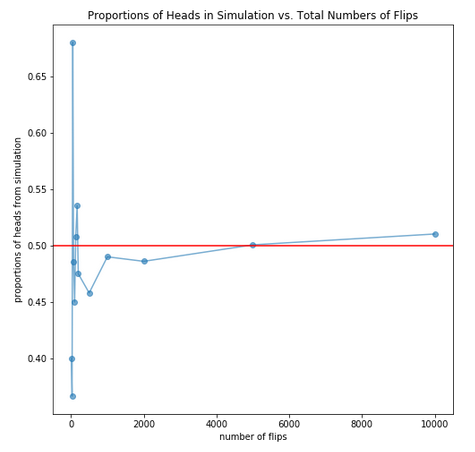

```python
from IPython.display import Image, display
from IPython.display import Image
Image('HW0Plot1.png')
```

#### Answers

**2.1**

```python
def get_count(throws, side):
    return np.sum([throw == side for throw in throws])

def get_proportion(throws, side):
    return get_count(throws, side) / len(throws)

def get_proportion_head(throws):
    return get_proportion(throws, 'H')

throws1 = throw_a_coin(40)
get_proportion_head(throws1)
```

```
0.525
```

**2.2**

```python
throws2 = throw_a_coin(40)
get_proportion_head(throws2)
```

```
0.375
```

**2.3**

```python
n_flips = [10, 30, 50, 70, 100, 130, 170, 200, 500, 1000, 2000, 5000, 10000]
```

```python
def run_trials(n_flips):
    return [get_proportion_head(throw_a_coin(flips)) for flips in n_flips]
```

```python
proportions = run_trials(n_flips)
proportions
```

```
[0.6,
 0.5333333333333333,
 0.54,
 0.4714285714285714,
 0.51,
 0.47692307692307695,
 0.4176470588235294,
 0.5,
 0.556,
 0.506,
 0.495,
 0.5012,
 0.4977]
```

**2.4**

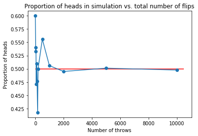

```python
x = n_flips
y = proportions

plt.plot(x, y, 'o-')
plt.xlabel("Number of throws")
plt.ylabel("Proportion of heads")
plt.title("Proportion of heads in simulation vs. total number of flips")

average_proportion = 0.5
min_x = 0
max_x = plt.xlim()[1]
plt.hlines(average_proportion, min_x, max_x, colors='r')
```

**2.5**

**What's the appropriate observation about the result of applying the coin flip experiment to larger and larger numbers of coin flips? Choose the appropriate one.**

B. The proportions **fluctuate** about their long-run value of 0.5 (what you might expect if you tossed the coin an infinite amount of times), in accordance with the notion of a fair coin (which we encoded in our simulation by having `np.random.choice` choose between two possibilities with equal probability), with the fluctuations seeming to become much smaller as the number of trials increases.

## Multiple Replications of the Coin Flip Experiment

The coin flip experiment that we did above gave us some insight, but we don't have a good notion of how robust our results are under repetition as we've only run one experiment for each number of coin flips. Lets redo the coin flip experiment, but let's incorporate multiple repetitions of each number of coin flips. For each choice of the number of flips, $n$, in an experiment, we'll do $M$ replications of the coin tossing experiment.

### Question 3:

**3.1**. Write a function `make_throws` which takes as arguments the `n_replications` ($M$) and the `n_flips` ($n$), and returns a list (of size $M$) of proportions, with each proportion calculated by taking the ratio of heads to to total number of coin flips in each replication of $n$ coin tosses. `n_flips` should be a python parameter whose value should default to 20 if unspecified when `make_throws` is called.

**3.2**. Create the variables `proportions_at_n_flips_100` and `proportions_at_n_flips_1000`. Store in these variables the result of `make_throws` for `n_flips` equal to 100 and 1000 respectively while keeping `n_replications` at 200. Create a plot with the histograms of `proportions_at_n_flips_100` and `proportions_at_n_flips_1000`. Make sure to title your plot, label the x-axis and provide a legend.(See below for an example of what the plot may look like)

[figure not shown]

**3.3**. Calculate the mean and variance of the results in the each of the variables `proportions_at_n_flips_100` and `proportions_at_n_flips_1000` generated in 3.2.

3.4. Based upon the plots what would be your guess of what type of distribution is represented by histograms in 3.2? Explain the factors that influenced your choice.

> A. Gamma Distribution

> B. Beta Distribution

> C. Gaussian

**3.5**. Let's just assume for arguments sake that the answer to 3.4 is **C. Gaussian**. Plot a **normed histogram** of your results `proportions_at_n_flips_1000` overlayed with your selection for the appropriate gaussian distribution to represent the experiment of flipping a coin 1000 times. (**Hint: What parameters should you use for your Gaussian?**)

#### Answers

**3.1**

```python
def make_throws(m_replications, n_flips=20):
    return [get_proportion_head(throw_a_coin(n_flips)) for _ in range(m_replications)]
```

**3.2**

```python
proportions_at_n_flips_100 = make_throws(200, 100)
proportions_at_n_flips_1000 = make_throws(200, 1000)
```

```
Text(0.5,1,'Histogram of samples at different number of flips')
```

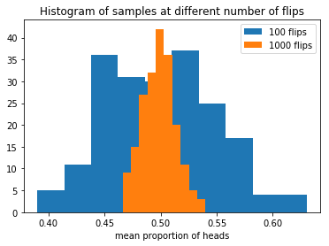

```python
plt.hist(proportions_at_n_flips_100, label="100 flips")
plt.hist(proportions_at_n_flips_1000, label="1000 flips")

plt.legend(loc="upper right")
plt.xlabel("mean proportion of heads")
plt.title("Histogram of samples at different number of flips")
```

**3.3**

```python
mean100 = np.mean(proportions_at_n_flips_100)
mean1000 = np.mean(proportions_at_n_flips_1000)
variance100 = np.var(proportions_at_n_flips_100)
variance1000 = np.var(proportions_at_n_flips_1000)

print('Mean of 100: {}\nVariance of 100: {}\nMean of 1000: {}\nVariance of 1000: {}'.format(mean100, variance100, mean1000, variance1000))
```

```
Mean of 100: 0.49924999999999997
Variance of 100: 0.0023009375000000005
Mean of 1000: 0.498485
Variance of 1000: 0.00021248977500000032
```

**3.4**

**ANSWER**

This seems to follow a Gaussian distribution. The form has a peek at the mean, and is relatively not skewed towards one side. As we get further from the mean, the frequency diminishes.

These are all traits of a normal (Gaussian) distribution.

**3.5**

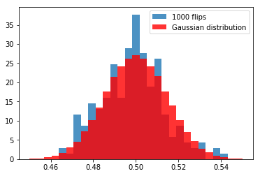

```python
bins = np.linspace(0.45,0.55, 30)
mean_of_gaussian = 0.5
standard_deviation_of_gaussian = np.sqrt(variance1000)
gaussian = [np.random.normal(mean_of_gaussian, standard_deviation_of_gaussian) for _ in range(100000)]

plt.hist(proportions_at_n_flips_1000, bins, label="1000 flips", density=True, alpha=0.8)
plt.hist(gaussian, bins, density=True, alpha=0.8, color="r", label="Gaussian distribution")
plt.legend(loc="upper right")
```

## Working With Distributions in Numpy/Scipy

Earlier in this problem set we've been introduced to the Bernoulli "aka coin-flip" distribution and worked with it indirectly by using np.random.choice to make a random selection between two elements 'H' and 'T'. Let's see if we can create comparable results by taking advantage of the machinery for working with other probability distributions in python using numpy and scipy.

### Question 4:

Let's use our coin-flipping machinery to do some experimentation with the binomial distribution. The binomial distribution, often represented by $k \sim Binomial(n, p)$ is often discribed the number of successes in `n` Bernoulli trials with each trial having a probability of success `p`. In other words, if you flip a coin `n` times, and each coin-flip has a probability `p` of landing heads, then the number of heads you observe is a sample from a bernoulli distribution.

**4.1**. Sample the binomial distribution with $p = 0.5$ using coin flips by writing a function `sample_binomial1` which takes in integer parameters `n` and `size`. The output of `sample_binomial1` should be a list of length `size` observations with each observation being the outcome of flipping a coin `n` times and counting the number of heads. By default `size` should be 1. Your code should take advantage of the `throw_a_coin` function we defined above.

**4.2**. Sample the binomial distribution directly using scipy.stats.binom.rvs by writing another function `sample_binomial2` that takes in integer parameters `n` and `size` as well as a float `p` parameter `p` where $p \in [0 \ldots 1]$. The output of `sample_binomial2` should be a list of length `size` observations with each observation a sample of $Binomial(n, p)$ (taking advantage of scipy.stats.binom). By default `size` should be 1 and `p` should be 0.5.

**4.3**. Run sample_binomial1 with 25 and 200 as values of the `n` and `size` parameters respectively and store the result in `binomial_trials1`. Run sample_binomial2 with 25, 200 and 0.5 as values of the `n`, `size` and `p` parameters respectively and store the results in `binomial_trials2`. Plot normed histograms of `binomial_trials1` and `binomial_trials2`. On both histograms, overlay a plot of the pdf of $Binomial(n=25, p=0.5)$

**4.4**. How do the plots in 4.3 compare?

**4.5**. Find the mean and variance of `binomial_trials1`. How do they compare to the mean and varaince of $Binomial(n=25, p=0.5)$

#### Answers

**4.1**

```python
def sample_binomial1(n, size=1):
    return [get_count(throw_a_coin(n), 'H') for _ in range(size)]
```

**4.2**

```python
def sample_binomial2(n, p=0.5, size=1):
    if p < 0 or p > 1:
        raise ValueError('Probability has to be [0,1]')

    return scipy.stats.binom.rvs(n, p, size=size)
```

**4.3**

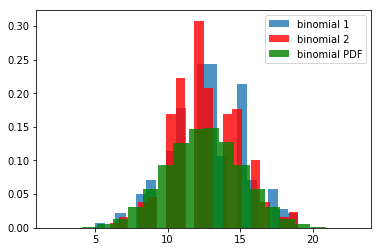

```python
bins = 20
binomial_trials1 = sample_binomial1(25, 200)
binomial_trials2 = sample_binomial2(25, size=200)
binomial = np.random.binomial(25, 0.5, size=500000)

plt.hist(binomial_trials1, bins, label="binomial 1", alpha=0.8, density=True)
plt.hist(binomial_trials2, bins, alpha=0.8, color="r", label="binomial 2", density=True)
plt.hist(binomial, bins, alpha=0.8, color='g', label="binomial PDF", density=True)
plt.legend(loc="upper right")
```

**4.4**

*binomial1* and *binomial2* both seem to have higher peaks around 12.5 compared to the PDF computed. They all seem to have a bell curve form, but some bins are empty, especially if we compare to the smooth PDF.

**4.5**

```python
mean_trial1 = np.mean(binomial_trials1)
variance_trial1 = np.var(binomial_trials1)
mean_binomial = np.mean(binomial)
variance_binomial = np.var(binomial)

print('Mean of trial1: {}\nVariance of trial1: {}\nMean of binomial: {}\nVariance of binomial: {}'.format(mean_trial1, variance_trial1, mean_binomial, variance_binomial))
```

```
Mean of trial1: 12.71
Variance of trial1: 6.6459
Mean of binomial: 12.498814
Variance of binomial: 6.242486593404001
```

The mean of a binomial distribution is *np*, so 12.5. The mean of our trial1 is 12.71, which gives it an error of 1.68%.

The variance of a binomial distribution is *np(1-p)*, so 6.25. The variance of our trial1 is 6.6459, which gives it an error of 6.33%.

## Sequences and Series

Many mathematical and physical constants can be expressed as infinite sums, infinite products, and limits of recursion relationships. In this problem, we will consider representations for two very famous numbers.

## $\pi$

One way to represent $\pi$ is with the infinite sum \begin{align*} \frac{\pi^{2}}{6} = \sum_{n=0}^{\infty}{\frac{1}{n^{2}}}. \end{align*}

## $\varphi$: the golden ratio

In this problem, you will write a function to compute $\pi$ and $\varphi$ from the representations just described.

### Question 5

**5.1** Write a function called `numbers` that uses the infinite series representation to calculate $\pi$ and the ratio of consecutive Fibonacci numbers to calculate $\varphi$.

#### Requirements

- The function should accept two arguments
  - Argument 1: A `string` indicating which number to calculate. The string can be either "pi" or "golden".
  - Argument 2: An `integer` to specify how many terms to use in the approximation. For example, if the integer is $10$ then the first $10$ terms of the sum for $\pi$ will be used.
- Depending on the arguments, the function will calculate either $\pi$ or $\varphi$.
- If the user supplies an unrecognized argument, then the function should fail with an informative error message.
- The function should return a `float` which represents either $\pi$ or $\varphi$.

#### Hints

**5.2** Calculate $\pi$ and $\varphi$ using a variety of different terms in the expansion or recursion.

#### Requirements

- Create a `python` `list` of integers. Each integer represents the number of terms in the series representation or the recursion relation.
- The list can be as big as you want, but should ascribe to the following:
  - For the $\pi$ expansion, you should use at least $15$ terms and go up to at least $500$.
  - For the $\varphi$ recursion, you should use the integers up to $10$. If you go too high, you will get an overflow.
- Iterate over the `list` and calculate $\pi$ and $\varphi$ at each item.
- Store the results in a list.

**5.3** Plot the approximate values of $\pi$ and $\varphi$ as a function of the number of terms.

#### Requirements

- Make two separate plots: one for $\pi$ and one for $\varphi$.
- On each figure, plot the true value of $\pi$ and $\varphi$ as a horizontal line.

#### Hints

- You may use `numpy` to get the true value.
- Your figure might look something like this:

[figure not shown]

#### Answers

**5.1**

```python
def numbers(number, precision):
    if not isinstance(precision, int) or precision < 3:
        raise ValueError("the second parameter (precision) must be an integer bigger than 2")

    if number != "pi" and number != "golden":
        raise ValueError("the first parameter (number) must be either \"pi\" or \"golden\"")

    result = calculatePi(precision) if number == "pi" else calculateGolden(precision)

    print("Result of {} with {} terms is: {}".format(number, precision, result))
    return result

def calculatePi(term):
    value = 0

    for n in range(1, term):
        value += 1 / n**2

    return np.sqrt(value * 6)

def calculateGolden(term):
    cache = {
        1: 1,
        2: 1,
    }

    return calculateGolden_rec(term-1, cache) / calculateGolden_rec(term-2, cache)

def calculateGolden_rec(term, cache):
    if term not in cache:
        cache[term] = calculateGolden_rec(term-1, cache) + calculateGolden_rec(term-2, cache)

    return cache[term]
```

**5.2**

```python
list_of_terms_pi = [4, 5, 6, 7, 8, 9, 10, 15, 20, 25, 30, 50, 100, 200, 500, 1000]
list_of_terms_golden = [3, 4, 5, 6, 7, 8, 9, 10, 11, 12, 13, 14, 15, 16, 17, 18, 19, 20, 50, 100]

results_pi = list(map(lambda n: numbers("pi", n), list_of_terms_pi))
results_golden = list(map(lambda n: numbers("golden", n), list_of_terms_golden))
```

```
Result of pi with 4 terms is: 2.8577380332470415
Result of pi with 5 terms is: 2.9226129861250305
Result of pi with 6 terms is: 2.9633877010385707
Result of pi with 7 terms is: 2.9913764947484185
Result of pi with 8 terms is: 3.011773947846214
Result of pi with 9 terms is: 3.027297856657843
Result of pi with 10 terms is: 3.0395075895610533
Result of pi with 15 terms is: 3.0750569155713614
Result of pi with 20 terms is: 3.092245052300697
Result of pi with 25 terms is: 3.1023765763598083
Result of pi with 30 terms is: 3.109056776410318
Result of pi with 50 terms is: 3.1222422074094722
Result of pi with 100 terms is: 3.1319807472443624
Result of pi with 200 terms is: 3.1368023967234504
Result of pi with 500 terms is: 3.139680301095856
Result of pi with 1000 terms is: 3.14063710098594
Result of golden with 3 terms is: 1.0
Result of golden with 4 terms is: 2.0
Result of golden with 5 terms is: 1.5
Result of golden with 6 terms is: 1.6666666666666667
Result of golden with 7 terms is: 1.6
Result of golden with 8 terms is: 1.625
Result of golden with 9 terms is: 1.6153846153846154
Result of golden with 10 terms is: 1.619047619047619
Result of golden with 11 terms is: 1.6176470588235294
Result of golden with 12 terms is: 1.6181818181818182
Result of golden with 13 terms is: 1.6179775280898876
Result of golden with 14 terms is: 1.6180555555555556
Result of golden with 15 terms is: 1.6180257510729614
Result of golden with 16 terms is: 1.6180371352785146
Result of golden with 17 terms is: 1.618032786885246
Result of golden with 18 terms is: 1.618034447821682
Result of golden with 19 terms is: 1.6180338134001253
Result of golden with 20 terms is: 1.618034055727554
Result of golden with 50 terms is: 1.618033988749895
Result of golden with 100 terms is: 1.618033988749895
```

**5.3**

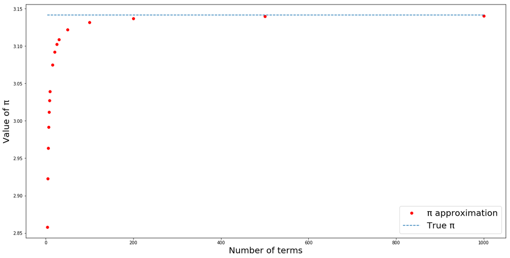

```python
list_of_terms_truePi = [list_of_terms_pi[0], list_of_terms_pi[-1]]
results_truePi = [np.pi, np.pi]

plt.figure(figsize=(20, 10))
plt.plot(list_of_terms_pi, results_pi, 'ro', label="π approximation")
plt.plot(list_of_terms_truePi, results_truePi, linestyle="dashed", label="True π")
plt.xlabel("Number of terms", fontsize=20)
plt.ylabel("Value of π", fontsize=20)
plt.legend(loc="lower right", fontsize=20)
```

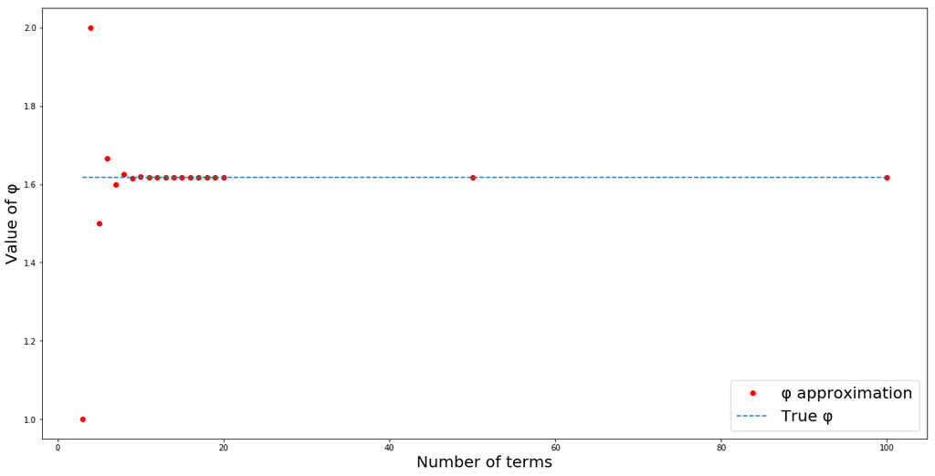

```python
list_of_terms_trueGolden = [list_of_terms_golden[0], list_of_terms_golden[-1]]
results_trueGolden = [sp.constants.golden, sp.constants.golden]

plt.figure(figsize=(20, 10))
plt.plot(list_of_terms_golden, results_golden, 'ro', label="φ approximation")
plt.plot(list_of_terms_trueGolden, results_trueGolden, linestyle="dashed", label="True φ")
plt.xlabel("Number of terms", fontsize=20)
plt.ylabel("Value of φ", fontsize=20)
plt.legend(loc="lower right", fontsize=20)
```